# Elastic Net

Wesley_Tao

2018/3/30

# 1.Goal and Objective

# 2.Data preprocessing and exploratory result

Some parts of putting data in a desirable format are not displayed for tidyness. But we could open linear_model.Rmd to see the code details.

But I do have to highlight some of the important parts of data processing.

### a How I choose first batch of varibles for lasso

Most of the variables in Cencus Data csv are irrelevant for our target.

```r
head(colnames(Census_data),10)
```

```
##  [1] "GEO.id2"           "GEO.display.label" "HC01_VC03"
##  [4] "HC02_VC03"         "HC03_VC03"         "HC04_VC03"
##  [7] "HC01_VC04"         "HC02_VC04"         "HC03_VC04"
## [10] "HC04_VC04"
```

However they are encoded with a pattern. VC## represent the variable, HC01 is the Estimate which is a real positive number  
HC02 is the Margin of the error  
HC03 is HC01/Population  
HC04 is HC02/Population  
Then the problem boils down to find the pattern of “HC03_VC##”

```r
X_pattern       <-"HC03_VC[0-9]+"# regular expression
newdata_colnames<-names(newdata)
X_index         <-grep(X_pattern,newdata_colnames)
head(newdata_colnames[X_index],10) # but HC03_VC_03 is the population
```

```
##  [1] "HC03_VC03" "HC03_VC04" "HC03_VC05" "HC03_VC06" "HC03_VC07"
##  [6] "HC03_VC08" "HC03_VC09" "HC03_VC11" "HC03_VC12" "HC03_VC14"
```

```r
length(newdata_colnames[X_index])
```

```
## [1] 137
```

There are 136 varibles and the first one is population for the county which will be used later.

## 2.2 Data Description

# 3.Exploratory result

# 4.Model Building

## 4.1 Lasso with regularization for feature selection

```r
X_index<-X_index[-1] # remove the first HC03_VC_03
y_index<-2
subset_index<-c(y_index,X_index) # combine with y
```

```r
# we also find some variables have (X) we have to get rid of them
head(newdata[,"HC03_VC118"])
```

```
## [1] "(X)" "(X)" "(X)" "(X)" "(X)" "(X)"
```

```r
newdata.subset<-apply(newdata[,subset_index],2,as.numeric)# these '(X)' will be automatically handled by as.integer and replaced by NA
# head(newdata.subset)
# it seems that we also have some variables which are population labor force, we have to get rid of them too
# rules are if value is larger than 200 then
log.index<-apply(newdata.subset,2,mean,na.rm=T)<200
new_index<-which(log.index)

cleaned_data<-newdata.subset[,new_index]
cleaned_data<-na.omit(cleaned_data) # omit na by row
```

# Train and test split

```r
# split the data for train and test
# 20% of the data as test data and 80 % as train data
set.seed(1)
total.num      <-nrow(cleaned_data)
test_index_row <-sample(seq(total.num),total.num*0.2)
train_index_row<-setdiff(seq(total.num),test_index_row)



X_test<-cleaned_data[test_index_row,-1]
y_test<-cleaned_data[test_index_row,1]

X_train<-cleaned_data[train_index_row,-1]
y_train<-cleaned_data[train_index_row,1]

length(test_index_row)+length(train_index_row)==total.num # make sure the number meet
```

```
## [1] TRUE
```

# Heat map of variable correlation

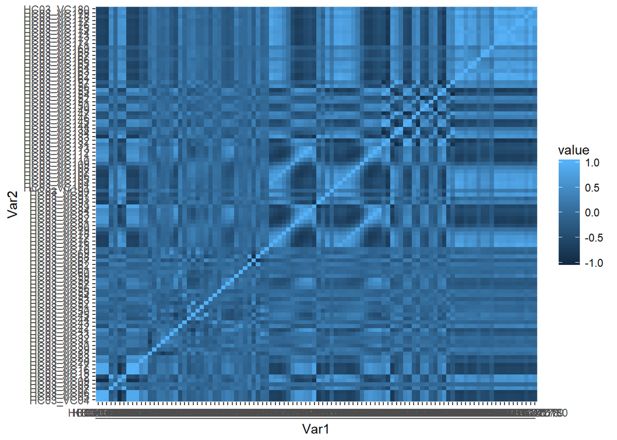

```r
library(ggplot2)
library(reshape2)
cormat       <-round(cor(X_train),2)
melted_cormat<-melt(cormat) # transform to a narrow format

ggplot(data = melted_cormat, aes(x=Var1, y=Var2, fill=value)) +
  geom_tile()
```

```r
# it seems that this data set has a lot of collinearity, It might cause a lot of problem, we need regularization
```

# Elastic Net for variable selection

My original idea is to use lasso for variable selection, however , we can see clearly that some of the X variables are highly correlated thus regularizaiton of L2 penalty is needed. for more details about the loss function of the model:

$$\min_{\beta_0,\beta}(\frac{1}{2N}\sum_{i=1}^{N}(y_i-\beta_0-x_i^T\beta)^2+\lambda[(1-\alpha)||\beta||_2^2/2+\alpha||\beta||_1)])$$
There are two parameters, one is $\alpha$ another is $\lambda$ . $\alpha$ is a compromise between Ridge($\alpha=0$) and Lasso regression ($\alpha=1$). We choose the ideal alpha based on 10-fold cross-validation. $\lambda$ is the penalty we put on the parameter.

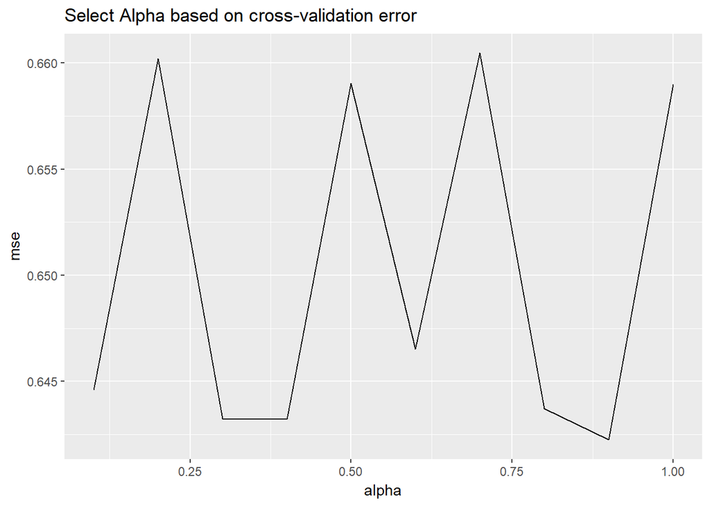

```r
library(glmnet)
# 5-fold Cross validation for each alpha = 0, 0.1, ... , 0.9, 1.0
set.seed(4)
alpha_seq<-seq(10)/10

result<-data.frame(alpha=alpha_seq,mse=rep(NA,length(alpha_seq)))# generate a data frame to store the result

for(i in 1:length(alpha_seq)){
  this.alpha <-alpha_seq[i]
  fit.reg.cv <- cv.glmnet(X_train, y_train,nfold=10, type.measure="mse", alpha=this.alpha,
                          family="gaussian")
  this.lambda<-fit.reg.cv$lambda.min # we choose lambda with the minimun mse

  yhat       <-predict(fit.reg.cv, s=this.lambda, newx=X_train) # get pred over the train set
  mse        <- mean((y_train - yhat)^2) #compute mse
  result[i,2]<-mse #

}

# plot mse over alpha
ggplot(data = result,aes(x=alpha,y=mse))+
  geom_line()+
  labs(title="Select Alpha based on cross-validation error")
```

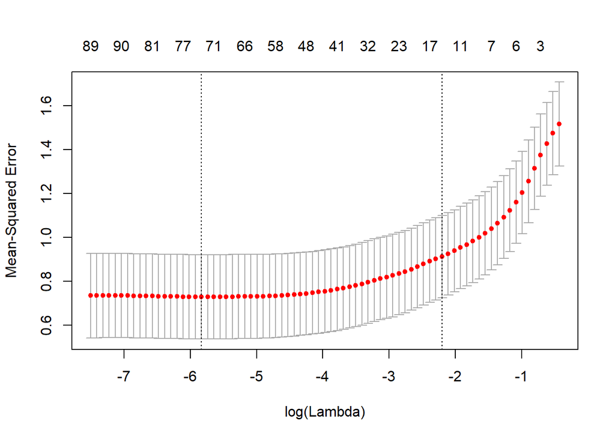

```r
set.seed(1)
fit.ela.cv <- cv.glmnet(X_train, y_train, type.measure="mse", alpha=0.9,
                          family="gaussian",nfolds = 5)
plot(fit.ela.cv)
```

```r
yhat <- predict(fit.ela.cv, s=fit.ela.cv$lambda.1se, newx=X_test)
test_mse <- mean((y_test - yhat)^2)
```

```r
test_mse
```

```
## [1] 0.613089
```

```r
# we are interested in those variabels
head(data.frame(n=fit.ela.cv$nzero,lambda=fit.ela.cv$lambda),14)
```

```
##     n    lambda
## s0  0 0.6478059
## s1  1 0.5902566
## s2  1 0.5378199
## s3  3 0.4900414
## s4  5 0.4465075
## s5  5 0.4068410
## s6  5 0.3706984
## s7  6 0.3377666
## s8  6 0.3077603
## s9  6 0.2804197
## s10 6 0.2555080
## s11 7 0.2328094
## s12 7 0.2121272
## s13 9 0.1932824
```

```r
# use full data
final_model<-glmnet(cleaned_data[,-1], cleaned_data[,1], alpha=0.9, lambda=0.1932824,
                          family="gaussian")
head(final_model$beta,10) # as we can see many variables are shrink to seros
```

```
## 10 x 1 sparse Matrix of class "dgCMatrix"
##                    s0
## HC03_VC04  .
## HC03_VC05  .
## HC03_VC06  .
## HC03_VC07 -0.05212367
## HC03_VC08  .
## HC03_VC09  .
## HC03_VC12  .
## HC03_VC15  .
## HC03_VC16  .
## HC03_VC17  .
```

we are interested in those non-zero varariables

```r
myvar<-which(final_model$beta!=0)
# final_model$beta
x_names<-colnames(cleaned_data)[-1]
data.frame(code=x_names[myvar],coe=final_model$beta[myvar])
```

```
##         code           coe
## 1  HC03_VC07 -5.212367e-02
## 2  HC03_VC23  1.934705e-02
## 3  HC03_VC50  1.126535e-02
## 4  HC03_VC69  9.183745e-02
## 5 HC03_VC101 -4.350882e-05
## 6 HC03_VC131  2.422074e-03
## 7 HC03_VC132  1.600232e-03
## 8 HC03_VC134 -3.506262e-03
## 9 HC03_VC164 -3.522046e-02
```

we are also interested what are these

```r
dex_index<-which(colnames(var_des) %in% x_names[myvar])
t(var_des[,dex_index])
```

```
##            1
## HC03_VC07  "Percent; EMPLOYMENT STATUS - Population 16 years and over - In labor force - Civilian labor force - Unemployed"
## HC03_VC23  "Percent; EMPLOYMENT STATUS - Own children of the householder 6 to 17 years - All parents in family in labor force"
## HC03_VC50  "Percent; INDUSTRY - Civilian employed population 16 years and over - Agriculture, forestry, fishing and hunting, and mining"
## HC03_VC69  "Percent; CLASS OF WORKER - Civilian employed population 16 years and over - Self-employed in own not incorporated business workers"
## HC03_VC101 "Percent; INCOME AND BENEFITS (IN 2016 INFLATION-ADJUSTED DOLLARS) - With Food Stamp/SNAP benefits in the past 12 months"
## HC03_VC131 "Percent; HEALTH INSURANCE COVERAGE - Civilian noninstitutionalized population - With health insurance coverage"
## HC03_VC132 "Percent; HEALTH INSURANCE COVERAGE - Civilian noninstitutionalized population - With health insurance coverage - With private health insurance"
## HC03_VC134 "Percent; HEALTH INSURANCE COVERAGE - Civilian noninstitutionalized population - No health insurance coverage"
## HC03_VC164 "Percent; PERCENTAGE OF FAMILIES AND PEOPLE WHOSE INCOME IN THE PAST 12 MONTHS IS BELOW THE POVERTY LEVEL - Married couple families"
```

# Conclusion

We found several varibles which are highly correlated to the social capital index, they are listed below.

1. Employment status (+)
2. Unemployed rate (-)
3. Health Insurance Coverage (+)
4. No Health cover (-)
5. Below Poverty (-)